# Basics of `mrgsolve`

Ashwin Karanam

July 16, 2020

# 1. About [`mrgsolve`](https://mrgsolve.github.io)

- `R` package for simulation from ODE-based models
  - Free, OpenSource, GitHub, CRAN
- Language
  - Models written in `C++` inside model specification format
  - General purpose solver: `ODEPACK` / `DLSODA` (`FORTRAN`)
  - Simulation workflow in `R`
- Hierarchical (population) simulation
  - `ID`, $\eta$, $\varepsilon$
- Integrated PK functionaility
  - Bolus, infusion, `F`, `ALAG`, `SS` etc, handled under the hood
  - 1- and 2-cmt PK models in closed-form
- `R` is it’s natural habitat

# 2. Installation

This is the trickiest part of mrgsolve. Once you figure it out, the rest will be easy. Please refer to [`installation instructions here`](https://github.com/metrumresearchgroup/mrgsolve/wiki/mrgsolve-Installation). Prerequisits are:

- `R`: https://cran.r-project.org/ (Currently R >= `3.1.2` is required)
- Seriously consider running in `Rstudio` if possible. This is not required but is recommended.
- Compilers: `C++` and `gfortran`

```r
install.packages("mrgsolve")
```

# 3. Getting started with `mrgsolve`

There are two main components of simulating with `mrgsolve`:

- Model specifications in a `C++` file
- Simulation specifics in a `R` Script

## 3.1. Model specifications

The model file for `mrgsolve` is written in `C++` syntax and saved as a `.cpp` file. Language and format is quite similar to `NONMEM`, so NONMEMers will find the transition quite simple. While there are several blocks with in the `.cpp` file, we will be looking at an example with the most frequently used ones. For more details please refer to the [`model specification help document`](https://mrgsolve.github.io/user_guide/model-specification.html).

```r
#Begin .cpp file
#Starting with next line, we will write the mrgsolve model in C++esque synntax

//PROBLEM
//Two compartment model + extravascular absportion + nonlinear clearance

$PARAM
TVCL = 1, TVVC = 20, TVQ =2, TVVP = 10, TVKA = 1, TVVMAX = 0, TVKM   =  2

$CMT  @annotated
// similar to $MODEL in NONMEM
// if @annotated is not used, simpley declare compartment names with a space

EV1    : First extravascular compartment (mass)
CENT   : Central compartment (mass)
PERIPH : Peripheral compartment (mass)

$MAIN
//akin to $PK block in NONMEM

double CL   = TVCL*exp(ETA(1));
double VC   = TVVC*exp(ETA(2));
double Q    = TVQ;
double VP   = TVVP;
double KA   = TVKA;
double VMAX = TVVMAX;
double KM   = TVKM;


$GLOBAL
// declare variables you want to either use further in computation
// OR derive variables you want calculated from computations

//int TEST = 1; // declaring variables needs ";" at the end
#define CP (CENT/VC) // # define does not require ";"
#define CT (PERIPH/VP)
#define CLNL (VMAX/(KM+CP))

$OMEGA @block
// generates a block matrix with the formulation (1,1), (1,2), (2,2)....
// @correlation will specify values to be corrleations instead as variances

0.1 0.02 0.3

$SIGMA
// sigma variances go here

0.01

$ODE
//similar to $DES in NONMEM
//differential equations go here

dxdt_EV1 = -KA*EV1;
dxdt_CENT = KA*EV1 - (CL+CLNL+Q)*CP  + Q*CT;
dxdt_PERIPH = Q*CP - Q*CT;

$TABLE
// Use $TABLE to interact with parameters, compartment values,
// and other user-defined variables after the system advances to the next time
// double CP = (CENT/VC);

double DV = CP * (1 + EPS(1));

$CAPTURE
//This is a block to identify variables that should be captured in the simulated output

CP, DV
```

## 3.2. Simulation spcifications

### 3.2.1. Reading the model into R

Let’s start with `R` part. The first thing you will want to do is read your model file into `REnv` using `mrgsolve`.

```r
# Call libraries
library(tidyverse)
library(mrgsolve)
library(gridExtra)
```

```r
# mread("model","file-location")
mod <- mread("2cmtnl") # mread_cache() and mread_file() are variations
```

```
## Building 2cmtnl ... done.
```

```r
#?mread()
```

Let’s take a look at the model

```r
mod
```

```
##
##
## ----------------  source: 2cmtnl.cpp  ----------------
##
##   project: C:/Users/ashwi/D... 6 - mrgsolve
##   shared object: 2cmtnl-so-4274473338df
##
##   time:          start: 0 end: 24 delta: 1
##                  add: <none>
##
##   compartments:  EV1 CENT PERIPH [3]
##   parameters:    TVCL TVVC TVQ TVVP TVKA TVVMAX TVKM [7]
##   captures:      CP DV [2]
##   omega:         2x2
##   sigma:         1x1
##
##   solver:        atol: 1e-08 rtol: 1e-08 maxsteps: 20k
## ------------------------------------------------------
```

```r
param(mod)
```

```
##
##  Model parameters (N=7):
##  name value . name   value
##  TVCL 1     | TVVC   20
##  TVKA 1     | TVVMAX 10
##  TVKM 2     | TVVP   10
##  TVQ  2     | .      .
```

```r
init(mod)
```

```
##
##  Model initial conditions (N=3):
##  name       value . name         value
##  CENT (2)   0     | PERIPH (3)   0
##  EV1 (1)    0     | . ...        .
```

### 3.2.2. Sequence of simulation

Let’s now see how to simulate. The sequence for simulation is quite simple. Pipes come in handy. Simulations will a variation of one of the following:

- `model` %>% `intervention` %>% `options` %>% Go! %>% …
- `model` %>% `intervention` %>% `population` %>% Go! %>% …
- `model` %>% `data-set` %>% Go! %>% …
  - where `data-set` = `intervention + population`

### 3.2.3. Interventions/Dosing Events

Simulations are run with `mrgsim()`. Details will be described later. Let us now look at creating interventions. They are called dosing events and the function used is `ev()`. Things to include in `ev()`:

- `time` event time
- `cmt` Event compartment
- `amt` Dose amount
- `ii` Inter-dose interval
- `addl` Additional doses to administer
- `rate` Infusion rate
  - rate = 0 is bolus
  - rate > 0 is zero order infusion (`evid` 1)
- `ss` Set to 1 to advance to steady state
- `evid` Event id.
  - `evid` 2 is for “other”
  - `evid` 3 is for compartment reset
  - `evid` 4 is reset and dose
- `ID` Subject ID (use multiple ids - ID = 1:10)

Let’s look at a few interventions:

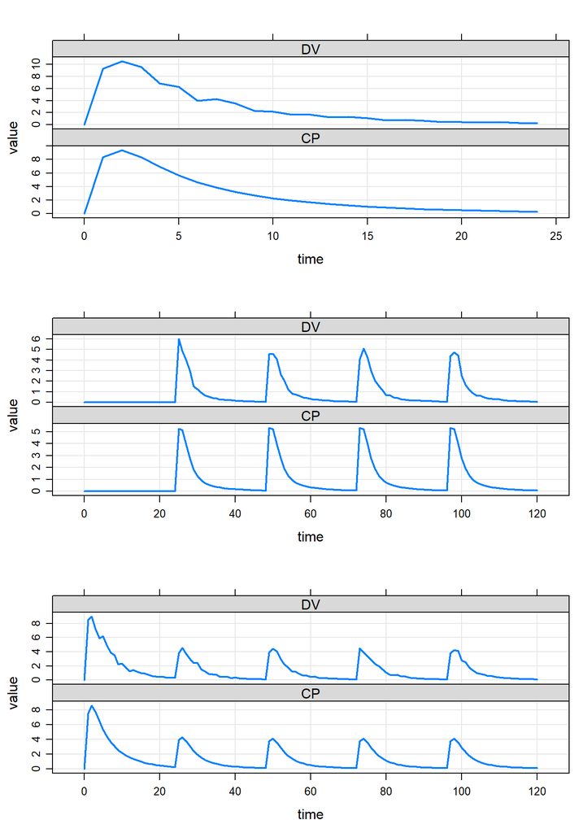

```r
e1 <- ev(amt = 200)
e2 <- ev(amt = 100, time = 24, ii = 24, addl = 4)
e3 <- c(e1,e2)

set.seed(07192020)
p1 <- mod %>% req(CP,DV) %>% ev(e1) %>% mrgsim() %>% plot()
p2 <- mod %>% req(CP,DV) %>% ev(e2) %>% mrgsim(end=24*5) %>% plot()
p3 <- mod %>% req(CP,DV) %>% ev(e3) %>% mrgsim(end=24*5) %>% plot()

grid.arrange(p1,p2,p3,ncol=1)
```

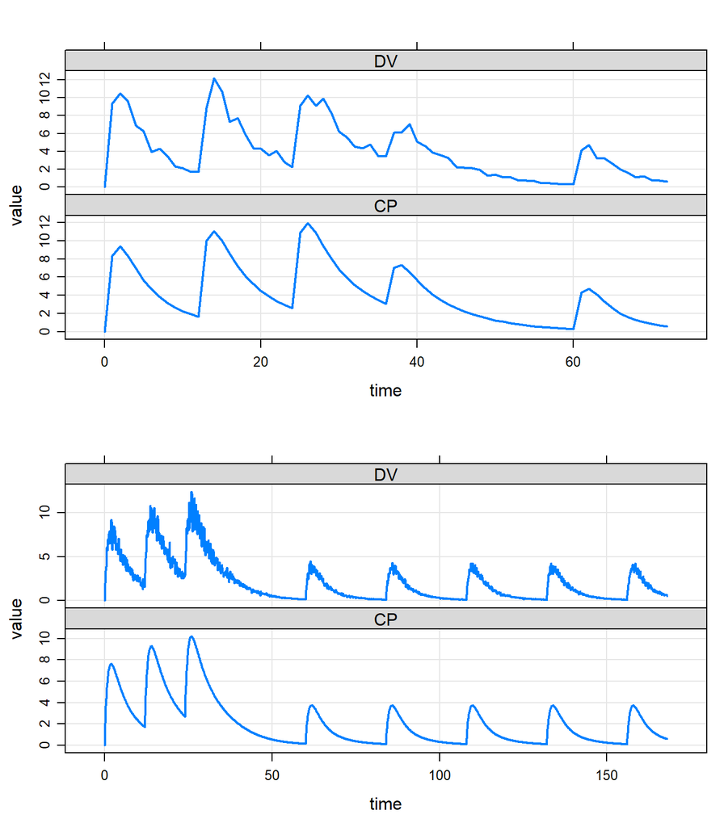

```r
# You could also add them in sequence

e1 <- ev(amt = 200, ii = 12, addl = 2)
e2 <- ev(amt = 100, ii = 24, addl = 4)
e3 <- seq(e1, e2)
e4 <- seq(e1, wait = 24, e2)

set.seed(07192020)
p1 <- mod %>% req(CP,DV) %>% ev(e3) %>% mrgsim(end=24*3,delta=1) %>% plot()
p2 <- mod %>% req(CP,DV) %>% ev(e4) %>% mrgsim(end=24*7,delta=0.1) %>% plot()

grid.arrange(p1,p2,ncol=1)
```

These are for individual simulations. Now let’s take a look at simulating populations.

### 3.2.4. Population level simulations

```r
# If individual level parameters avaliable

idata <- expand.idata(TVCL = seq(0.5, 1.5, 0.25))
idata
```

```
##   ID TVCL
## 1  1 0.50
## 2  2 0.75
## 3  3 1.00
## 4  4 1.25
## 5  5 1.50
```

```r
# Another formulation
# Can also carry parameters
data <- expand.ev(amt = c(100, 300, 1000), ii = 24, addl = 3)
head(data)
```

```
##   ID time  amt ii addl cmt evid
## 1  1    0  100 24    3   1    1
## 2  2    0  300 24    3   1    1
## 3  3    0 1000 24    3   1    1
```

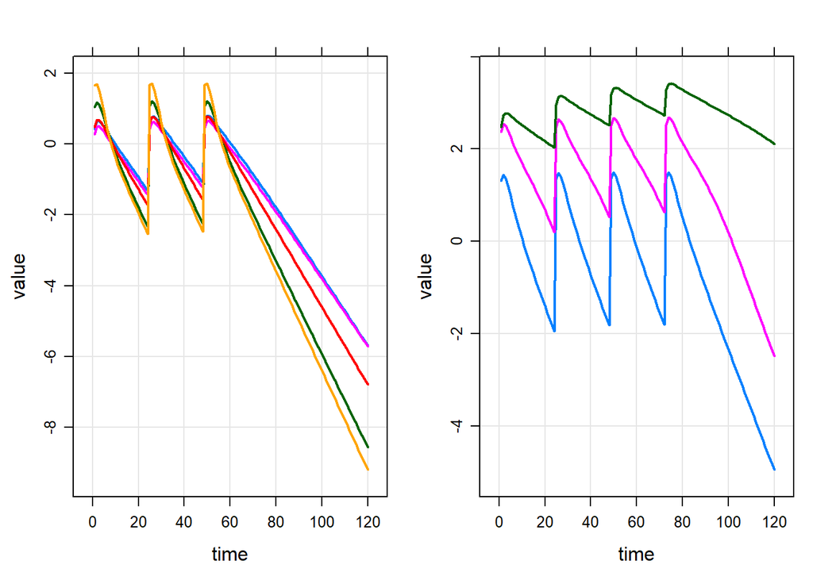

```r
# Let's simulate both
set.seed(07192020)
p1 <- mod %>%
  idata_set(idata) %>%
  ev(amt = 100, ii = 24, addl = 2) %>%
  mrgsim(end = 120) %>% plot(log(CP) ~ .)

p2 <- mod %>%
  data_set(data) %>%
  mrgsim(end = 120) %>% plot(log(CP) ~ .)

grid.arrange(p1,p2,ncol=2)
```

Let’s look at generating more population datasets

```r
# Combinations using exapnd.ev
expand.ev(ID = 1:2, amt = c(100,200))
```

```
##   ID time amt cmt evid
## 1  1    0 100   1    1
## 2  2    0 100   1    1
## 3  3    0 200   1    1
## 4  4    0 200   1    1
```

```r
# More datasets
as_data_set(
  ev(amt = 100, ii = 12, addl = 19, ID = 1:2),
  ev(amt = 200, ii = 24, addl = 9,  ID = 1:3),
  ev(amt = 150, ii = 24, addl = 9,  ID = 1:4)
)
```

```
##   ID time cmt evid amt ii addl
## 1  1    0   1    1 100 12   19
## 2  2    0   1    1 100 12   19
## 3  3    0   1    1 200 24    9
## 4  4    0   1    1 200 24    9
## 5  5    0   1    1 200 24    9
## 6  6    0   1    1 150 24    9
## 7  7    0   1    1 150 24    9
## 8  8    0   1    1 150 24    9
## 9  9    0   1    1 150 24    9
```

### 3.4.5. Updating parameters in the model

Now, let’s take a look at updating typical parameters in the model rather than for individual

```r
#Use param() to update $param block elements
param(mod)
```

```
##
##  Model parameters (N=7):
##  name value . name   value
##  TVCL 1     | TVVC   20
##  TVKA 1     | TVVMAX 10
##  TVKM 2     | TVVP   10
##  TVQ  2     | .      .
```

```r
mod2 <- mod %>% param(TVVC = 30)
param(mod2)
```

```
##
##  Model parameters (N=7):
##  name value . name   value
##  TVCL 1     | TVVC   30
##  TVKA 1     | TVVMAX 10
##  TVKM 2     | TVVP   10
##  TVQ  2     | .      .
```

```r
#Use omat() to update $omega block elements
omat(mod)
```

```
## $...
##     [,1] [,2]
## 1:  0.10 0.02
## 2:  0.02 0.30
```

```r
mod3 <- mod %>% omat(bmat(0.2,0.01,0.3)) #use damt() for diagonal matrix
omat(mod3)
```

```
## $...
##     [,1] [,2]
## 1:  0.20 0.01
## 2:  0.01 0.30
```

```r
#Use smat() to update $sigma block elements
smat(mod)
```

```
## $...
##     [,1]
## 1:  0.01
```

```r
mod4 <- mod %>% smat(dmat(0.2)) #use bamt() for block diagonal matrix
smat(mod4)
```

```
## $...
##     [,1]
## 1:   0.2
```

# Useful Resources

- https://github.com/mrgsolve/learn
- GitHub site: https://github.com/metrumresearchgroup/mrgsolve
- mrgsolve website: https://mrgsolve.github.io
- User Guide: https://mrgsolve.github.io/user_guide